# Risk Factor Analysis

## Outcome Variable

**Outcome Variable:** ever_wasted

## Predictor Variables

**Intervention Variable:** cleanck

**Adjustment Set:**

- arm
- sex
- W_mage
- meducyrs
- feducyrs
- hhwealth_quart
- W_nrooms
- W_nhh
- W_nchldlt5
- trth2o
- impfloor
- delta_meducyrs
- delta_feducyrs
- delta_hhwealth_quart
- delta_W_nrooms
- delta_W_nhh
- delta_W_nchldlt5
- delta_trth2o
- delta_impfloor

## Stratifying Variables

The analysis was stratified on these variable(s):

- agecat
- studyid
- country

## Data Summary

| agecat | studyid | country | cleanck | ever_wasted | n_cell | n |
| --- | --- | --- | --- | --- | --- | --- |
| 0-24 months (no birth wast) | ki0047075b-MAL-ED | PERU | 1 | 0 | 1 | 2 |
| 0-24 months (no birth wast) | ki0047075b-MAL-ED | PERU | 1 | 1 | 0 | 2 |
| 0-24 months (no birth wast) | ki0047075b-MAL-ED | PERU | 0 | 0 | 1 | 2 |
| 0-24 months (no birth wast) | ki0047075b-MAL-ED | PERU | 0 | 1 | 0 | 2 |
| 0-24 months (no birth wast) | ki0047075b-MAL-ED | SOUTH AFRICA | 1 | 0 | 2 | 3 |
| 0-24 months (no birth wast) | ki0047075b-MAL-ED | SOUTH AFRICA | 1 | 1 | 0 | 3 |
| 0-24 months (no birth wast) | ki0047075b-MAL-ED | SOUTH AFRICA | 0 | 0 | 1 | 3 |
| 0-24 months (no birth wast) | ki0047075b-MAL-ED | SOUTH AFRICA | 0 | 1 | 0 | 3 |
| 0-24 months (no birth wast) | ki1000108-CMC-V-BCS-2002 | INDIA | 1 | 0 | 104 | 368 |
| 0-24 months (no birth wast) | ki1000108-CMC-V-BCS-2002 | INDIA | 1 | 1 | 59 | 368 |
| 0-24 months (no birth wast) | ki1000108-CMC-V-BCS-2002 | INDIA | 0 | 0 | 98 | 368 |
| 0-24 months (no birth wast) | ki1000108-CMC-V-BCS-2002 | INDIA | 0 | 1 | 107 | 368 |
| 0-24 months (no birth wast) | ki1000108-IRC | INDIA | 1 | 0 | 107 | 399 |
| 0-24 months (no birth wast) | ki1000108-IRC | INDIA | 1 | 1 | 123 | 399 |
| 0-24 months (no birth wast) | ki1000108-IRC | INDIA | 0 | 0 | 84 | 399 |
| 0-24 months (no birth wast) | ki1000108-IRC | INDIA | 0 | 1 | 85 | 399 |
| 0-24 months (no birth wast) | ki1017093b-PROVIDE | BANGLADESH | 1 | 0 | 471 | 687 |
| 0-24 months (no birth wast) | ki1017093b-PROVIDE | BANGLADESH | 1 | 1 | 90 | 687 |
| 0-24 months (no birth wast) | ki1017093b-PROVIDE | BANGLADESH | 0 | 0 | 94 | 687 |
| 0-24 months (no birth wast) | ki1017093b-PROVIDE | BANGLADESH | 0 | 1 | 32 | 687 |
| 0-24 months (no birth wast) | ki1017093c-NIH-Crypto | BANGLADESH | 1 | 0 | 319 | 575 |
| 0-24 months (no birth wast) | ki1017093c-NIH-Crypto | BANGLADESH | 1 | 1 | 39 | 575 |
| 0-24 months (no birth wast) | ki1017093c-NIH-Crypto | BANGLADESH | 0 | 0 | 181 | 575 |
| 0-24 months (no birth wast) | ki1017093c-NIH-Crypto | BANGLADESH | 0 | 1 | 36 | 575 |
| 0-24 months (no birth wast) | ki1113344-GMS-Nepal | NEPAL | 1 | 0 | 7 | 589 |
| 0-24 months (no birth wast) | ki1113344-GMS-Nepal | NEPAL | 1 | 1 | 2 | 589 |
| 0-24 months (no birth wast) | ki1113344-GMS-Nepal | NEPAL | 0 | 0 | 279 | 589 |
| 0-24 months (no birth wast) | ki1113344-GMS-Nepal | NEPAL | 0 | 1 | 301 | 589 |
| 0-6 months (no birth wast) | ki0047075b-MAL-ED | PERU | 1 | 0 | 1 | 2 |
| 0-6 months (no birth wast) | ki0047075b-MAL-ED | PERU | 1 | 1 | 0 | 2 |
| 0-6 months (no birth wast) | ki0047075b-MAL-ED | PERU | 0 | 0 | 1 | 2 |
| 0-6 months (no birth wast) | ki0047075b-MAL-ED | PERU | 0 | 1 | 0 | 2 |
| 0-6 months (no birth wast) | ki0047075b-MAL-ED | SOUTH AFRICA | 1 | 0 | 2 | 3 |
| 0-6 months (no birth wast) | ki0047075b-MAL-ED | SOUTH AFRICA | 1 | 1 | 0 | 3 |
| 0-6 months (no birth wast) | ki0047075b-MAL-ED | SOUTH AFRICA | 0 | 0 | 1 | 3 |
| 0-6 months (no birth wast) | ki0047075b-MAL-ED | SOUTH AFRICA | 0 | 1 | 0 | 3 |
| 0-6 months (no birth wast) | ki1000108-CMC-V-BCS-2002 | INDIA | 1 | 0 | 117 | 350 |
| 0-6 months (no birth wast) | ki1000108-CMC-V-BCS-2002 | INDIA | 1 | 1 | 40 | 350 |
| 0-6 months (no birth wast) | ki1000108-CMC-V-BCS-2002 | INDIA | 0 | 0 | 125 | 350 |
| 0-6 months (no birth wast) | ki1000108-CMC-V-BCS-2002 | INDIA | 0 | 1 | 68 | 350 |
| 0-6 months (no birth wast) | ki1000108-IRC | INDIA | 1 | 0 | 136 | 381 |
| 0-6 months (no birth wast) | ki1000108-IRC | INDIA | 1 | 1 | 86 | 381 |
| 0-6 months (no birth wast) | ki1000108-IRC | INDIA | 0 | 0 | 115 | 381 |
| 0-6 months (no birth wast) | ki1000108-IRC | INDIA | 0 | 1 | 44 | 381 |
| 0-6 months (no birth wast) | ki1017093b-PROVIDE | BANGLADESH | 1 | 0 | 530 | 683 |
| 0-6 months (no birth wast) | ki1017093b-PROVIDE | BANGLADESH | 1 | 1 | 27 | 683 |
| 0-6 months (no birth wast) | ki1017093b-PROVIDE | BANGLADESH | 0 | 0 | 116 | 683 |
| 0-6 months (no birth wast) | ki1017093b-PROVIDE | BANGLADESH | 0 | 1 | 10 | 683 |
| 0-6 months (no birth wast) | ki1017093c-NIH-Crypto | BANGLADESH | 1 | 0 | 351 | 572 |
| 0-6 months (no birth wast) | ki1017093c-NIH-Crypto | BANGLADESH | 1 | 1 | 4 | 572 |
| 0-6 months (no birth wast) | ki1017093c-NIH-Crypto | BANGLADESH | 0 | 0 | 208 | 572 |
| 0-6 months (no birth wast) | ki1017093c-NIH-Crypto | BANGLADESH | 0 | 1 | 9 | 572 |
| 0-6 months (no birth wast) | ki1113344-GMS-Nepal | NEPAL | 1 | 0 | 7 | 576 |
| 0-6 months (no birth wast) | ki1113344-GMS-Nepal | NEPAL | 1 | 1 | 1 | 576 |
| 0-6 months (no birth wast) | ki1113344-GMS-Nepal | NEPAL | 0 | 0 | 456 | 576 |
| 0-6 months (no birth wast) | ki1113344-GMS-Nepal | NEPAL | 0 | 1 | 112 | 576 |
| 6-24 months | ki0047075b-MAL-ED | SOUTH AFRICA | 1 | 0 | 1 | 1 |
| 6-24 months | ki0047075b-MAL-ED | SOUTH AFRICA | 1 | 1 | 0 | 1 |
| 6-24 months | ki0047075b-MAL-ED | SOUTH AFRICA | 0 | 0 | 0 | 1 |
| 6-24 months | ki0047075b-MAL-ED | SOUTH AFRICA | 0 | 1 | 0 | 1 |
| 6-24 months | ki1000108-CMC-V-BCS-2002 | INDIA | 1 | 0 | 128 | 373 |
| 6-24 months | ki1000108-CMC-V-BCS-2002 | INDIA | 1 | 1 | 35 | 373 |
| 6-24 months | ki1000108-CMC-V-BCS-2002 | INDIA | 0 | 0 | 146 | 373 |
| 6-24 months | ki1000108-CMC-V-BCS-2002 | INDIA | 0 | 1 | 64 | 373 |
| 6-24 months | ki1000108-IRC | INDIA | 1 | 0 | 166 | 400 |
| 6-24 months | ki1000108-IRC | INDIA | 1 | 1 | 65 | 400 |
| 6-24 months | ki1000108-IRC | INDIA | 0 | 0 | 110 | 400 |
| 6-24 months | ki1000108-IRC | INDIA | 0 | 1 | 59 | 400 |
| 6-24 months | ki1017093b-PROVIDE | BANGLADESH | 1 | 0 | 437 | 615 |
| 6-24 months | ki1017093b-PROVIDE | BANGLADESH | 1 | 1 | 71 | 615 |
| 6-24 months | ki1017093b-PROVIDE | BANGLADESH | 0 | 0 | 79 | 615 |
| 6-24 months | ki1017093b-PROVIDE | BANGLADESH | 0 | 1 | 28 | 615 |
| 6-24 months | ki1017093c-NIH-Crypto | BANGLADESH | 1 | 0 | 306 | 559 |
| 6-24 months | ki1017093c-NIH-Crypto | BANGLADESH | 1 | 1 | 37 | 559 |
| 6-24 months | ki1017093c-NIH-Crypto | BANGLADESH | 0 | 0 | 186 | 559 |
| 6-24 months | ki1017093c-NIH-Crypto | BANGLADESH | 0 | 1 | 30 | 559 |
| 6-24 months | ki1113344-GMS-Nepal | NEPAL | 1 | 0 | 6 | 529 |
| 6-24 months | ki1113344-GMS-Nepal | NEPAL | 1 | 1 | 2 | 529 |
| 6-24 months | ki1113344-GMS-Nepal | NEPAL | 0 | 0 | 269 | 529 |
| 6-24 months | ki1113344-GMS-Nepal | NEPAL | 0 | 1 | 252 | 529 |

The following strata were considered:

- agecat: 0-24 months (no birth wast), studyid: ki0047075b-MAL-ED, country: PERU
- agecat: 0-24 months (no birth wast), studyid: ki0047075b-MAL-ED, country: SOUTH AFRICA
- agecat: 0-24 months (no birth wast), studyid: ki1000108-CMC-V-BCS-2002, country: INDIA
- agecat: 0-24 months (no birth wast), studyid: ki1000108-IRC, country: INDIA
- agecat: 0-24 months (no birth wast), studyid: ki1017093b-PROVIDE, country: BANGLADESH
- agecat: 0-24 months (no birth wast), studyid: ki1017093c-NIH-Crypto, country: BANGLADESH
- agecat: 0-24 months (no birth wast), studyid: ki1113344-GMS-Nepal, country: NEPAL
- agecat: 0-6 months (no birth wast), studyid: ki0047075b-MAL-ED, country: PERU
- agecat: 0-6 months (no birth wast), studyid: ki0047075b-MAL-ED, country: SOUTH AFRICA
- agecat: 0-6 months (no birth wast), studyid: ki1000108-CMC-V-BCS-2002, country: INDIA
- agecat: 0-6 months (no birth wast), studyid: ki1000108-IRC, country: INDIA
- agecat: 0-6 months (no birth wast), studyid: ki1017093b-PROVIDE, country: BANGLADESH
- agecat: 0-6 months (no birth wast), studyid: ki1017093c-NIH-Crypto, country: BANGLADESH
- agecat: 0-6 months (no birth wast), studyid: ki1113344-GMS-Nepal, country: NEPAL
- agecat: 6-24 months, studyid: ki0047075b-MAL-ED, country: SOUTH AFRICA
- agecat: 6-24 months, studyid: ki1000108-CMC-V-BCS-2002, country: INDIA
- agecat: 6-24 months, studyid: ki1000108-IRC, country: INDIA
- agecat: 6-24 months, studyid: ki1017093b-PROVIDE, country: BANGLADESH
- agecat: 6-24 months, studyid: ki1017093c-NIH-Crypto, country: BANGLADESH
- agecat: 6-24 months, studyid: ki1113344-GMS-Nepal, country: NEPAL

### Dropped Strata

Some strata were dropped due to rare outcomes:

- agecat: 0-24 months (no birth wast), studyid: ki0047075b-MAL-ED, country: PERU
- agecat: 0-24 months (no birth wast), studyid: ki0047075b-MAL-ED, country: SOUTH AFRICA
- agecat: 0-24 months (no birth wast), studyid: ki1113344-GMS-Nepal, country: NEPAL
- agecat: 0-6 months (no birth wast), studyid: ki0047075b-MAL-ED, country: PERU
- agecat: 0-6 months (no birth wast), studyid: ki0047075b-MAL-ED, country: SOUTH AFRICA
- agecat: 0-6 months (no birth wast), studyid: ki1017093c-NIH-Crypto, country: BANGLADESH
- agecat: 0-6 months (no birth wast), studyid: ki1113344-GMS-Nepal, country: NEPAL
- agecat: 6-24 months, studyid: ki0047075b-MAL-ED, country: SOUTH AFRICA
- agecat: 6-24 months, studyid: ki1113344-GMS-Nepal, country: NEPAL

## Methods Detail

We’re interested in the causal parameters $E[Y_a]$ for all values of $a \in \mathcal{A}$. These parameters represent the mean outcome if, possibly contrary to fact, we intervened to set all units to have $A=a$. Under the randomization and positivity assumptions, these are identified by the statistical parameters $\psi_a=E_W[E_{Y|A,W}(Y|A=a,W)]$. In addition, we’re interested in the mean of $Y$, $E[Y]$ under no intervention (the observed mean). We will estimate these parameters by using SuperLearner to fit the relevant likelihood factors – $E_{Y|A,W}(Y|A=a,W)$ and $p(A=a|W)$, and then updating our likelihood fit using a joint TMLE.

For unadjusted analyses ($W=\{\}$), initial likelihoods were estimated using Lrnr_glm to estimate the simple $E(Y|A)$ and Lrnr_mean to estimate $p(A)$. For adjusted analyses, a small library containing Lrnr_glmnet, Lrnr_xgboost, and Lrnr_mean was used.

Having estimated these parameters, we will then use the delta method to estimate relative risks and attributable risks relative to a prespecified baseline level of $A$.

# Results Detail

## Results Plots

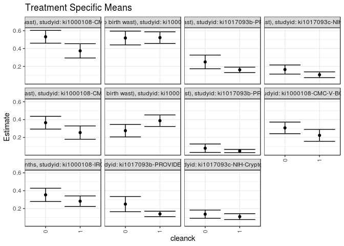

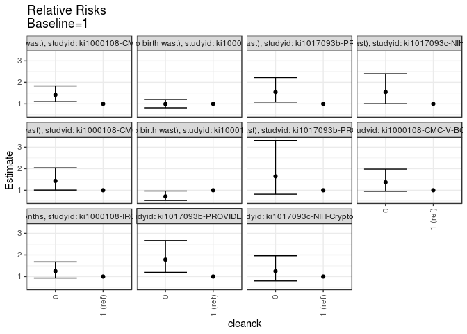

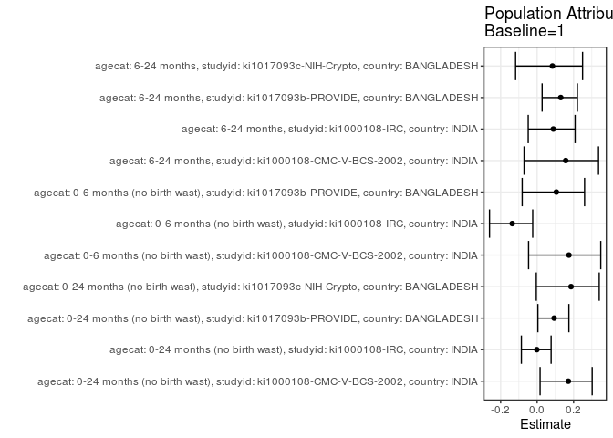

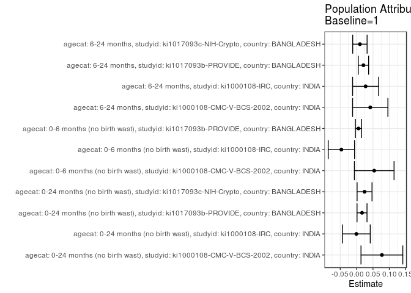

## Results Table

### Parameter: TSM

| agecat | studyid | country | intervention_level | baseline_level | estimate | ci_lower | ci_upper |
| --- | --- | --- | --- | --- | --- | --- | --- |
| 0-24 months (no birth wast) | ki1000108-CMC-V-BCS-2002 | INDIA | 1 | NA | 0.3737961 | 0.2938090 | 0.4537833 |
| 0-24 months (no birth wast) | ki1000108-CMC-V-BCS-2002 | INDIA | 0 | NA | 0.5313363 | 0.4596069 | 0.6030657 |
| 0-24 months (no birth wast) | ki1000108-IRC | INDIA | 1 | NA | 0.5220758 | 0.4569968 | 0.5871549 |
| 0-24 months (no birth wast) | ki1000108-IRC | INDIA | 0 | NA | 0.5178952 | 0.4405755 | 0.5952148 |
| 0-24 months (no birth wast) | ki1017093b-PROVIDE | BANGLADESH | 1 | NA | 0.1610379 | 0.1306436 | 0.1914322 |
| 0-24 months (no birth wast) | ki1017093b-PROVIDE | BANGLADESH | 0 | NA | 0.2498422 | 0.1732994 | 0.3263850 |
| 0-24 months (no birth wast) | ki1017093c-NIH-Crypto | BANGLADESH | 1 | NA | 0.1061664 | 0.0740788 | 0.1382540 |
| 0-24 months (no birth wast) | ki1017093c-NIH-Crypto | BANGLADESH | 0 | NA | 0.1648697 | 0.1137573 | 0.2159821 |
| 0-6 months (no birth wast) | ki1000108-CMC-V-BCS-2002 | INDIA | 1 | NA | 0.2547222 | 0.1801798 | 0.3292646 |
| 0-6 months (no birth wast) | ki1000108-CMC-V-BCS-2002 | INDIA | 0 | NA | 0.3652838 | 0.2938885 | 0.4366791 |
| 0-6 months (no birth wast) | ki1000108-IRC | INDIA | 1 | NA | 0.3877567 | 0.3232555 | 0.4522580 |
| 0-6 months (no birth wast) | ki1000108-IRC | INDIA | 0 | NA | 0.2762720 | 0.2061454 | 0.3463985 |
| 0-6 months (no birth wast) | ki1017093b-PROVIDE | BANGLADESH | 1 | NA | 0.0484615 | 0.0306114 | 0.0663117 |
| 0-6 months (no birth wast) | ki1017093b-PROVIDE | BANGLADESH | 0 | NA | 0.0796927 | 0.0322220 | 0.1271635 |
| 6-24 months | ki1000108-CMC-V-BCS-2002 | INDIA | 1 | NA | 0.2237476 | 0.1572530 | 0.2902421 |
| 6-24 months | ki1000108-CMC-V-BCS-2002 | INDIA | 0 | NA | 0.3071825 | 0.2423807 | 0.3719844 |
| 6-24 months | ki1000108-IRC | INDIA | 1 | NA | 0.2824811 | 0.2238556 | 0.3411067 |
| 6-24 months | ki1000108-IRC | INDIA | 0 | NA | 0.3533996 | 0.2792326 | 0.4275666 |
| 6-24 months | ki1017093b-PROVIDE | BANGLADESH | 1 | NA | 0.1401226 | 0.1099041 | 0.1703412 |
| 6-24 months | ki1017093b-PROVIDE | BANGLADESH | 0 | NA | 0.2498799 | 0.1651206 | 0.3346392 |
| 6-24 months | ki1017093c-NIH-Crypto | BANGLADESH | 1 | NA | 0.1098027 | 0.0768209 | 0.1427845 |
| 6-24 months | ki1017093c-NIH-Crypto | BANGLADESH | 0 | NA | 0.1370998 | 0.0910472 | 0.1831524 |

### Parameter: E(Y)

| agecat | studyid | country | intervention_level | baseline_level | estimate | ci_lower | ci_upper |
| --- | --- | --- | --- | --- | --- | --- | --- |
| 0-24 months (no birth wast) | ki1000108-CMC-V-BCS-2002 | INDIA | NA | NA | 0.4510870 | 0.4001777 | 0.5019962 |
| 0-24 months (no birth wast) | ki1000108-IRC | INDIA | NA | NA | 0.5213033 | 0.4722258 | 0.5703807 |
| 0-24 months (no birth wast) | ki1017093b-PROVIDE | BANGLADESH | NA | NA | 0.1775837 | 0.1489858 | 0.2061816 |
| 0-24 months (no birth wast) | ki1017093c-NIH-Crypto | BANGLADESH | NA | NA | 0.1304348 | 0.1028836 | 0.1579859 |
| 0-6 months (no birth wast) | ki1000108-CMC-V-BCS-2002 | INDIA | NA | NA | 0.3085714 | 0.2601110 | 0.3570318 |
| 0-6 months (no birth wast) | ki1000108-IRC | INDIA | NA | NA | 0.3412073 | 0.2935379 | 0.3888768 |
| 0-6 months (no birth wast) | ki1017093b-PROVIDE | BANGLADESH | NA | NA | 0.0541728 | 0.0371844 | 0.0711612 |
| 6-24 months | ki1000108-CMC-V-BCS-2002 | INDIA | NA | NA | 0.2654155 | 0.2205451 | 0.3102860 |
| 6-24 months | ki1000108-IRC | INDIA | NA | NA | 0.3100000 | 0.2646197 | 0.3553803 |
| 6-24 months | ki1017093b-PROVIDE | BANGLADESH | NA | NA | 0.1609756 | 0.1319065 | 0.1900447 |
| 6-24 months | ki1017093c-NIH-Crypto | BANGLADESH | NA | NA | 0.1198569 | 0.0929081 | 0.1468057 |

### Parameter: RR

| agecat | studyid | country | intervention_level | baseline_level | estimate | ci_lower | ci_upper |
| --- | --- | --- | --- | --- | --- | --- | --- |
| 0-24 months (no birth wast) | ki1000108-CMC-V-BCS-2002 | INDIA | 1 | 1 | 1.0000000 | 1.0000000 | 1.0000000 |
| 0-24 months (no birth wast) | ki1000108-CMC-V-BCS-2002 | INDIA | 0 | 1 | 1.4214602 | 1.1032866 | 1.8313909 |
| 0-24 months (no birth wast) | ki1000108-IRC | INDIA | 1 | 1 | 1.0000000 | 1.0000000 | 1.0000000 |
| 0-24 months (no birth wast) | ki1000108-IRC | INDIA | 0 | 1 | 0.9919922 | 0.8176256 | 1.2035442 |
| 0-24 months (no birth wast) | ki1017093b-PROVIDE | BANGLADESH | 1 | 1 | 1.0000000 | 1.0000000 | 1.0000000 |
| 0-24 months (no birth wast) | ki1017093b-PROVIDE | BANGLADESH | 0 | 1 | 1.5514497 | 1.0829897 | 2.2225475 |
| 0-24 months (no birth wast) | ki1017093c-NIH-Crypto | BANGLADESH | 1 | 1 | 1.0000000 | 1.0000000 | 1.0000000 |
| 0-24 months (no birth wast) | ki1017093c-NIH-Crypto | BANGLADESH | 0 | 1 | 1.5529360 | 1.0065419 | 2.3959363 |
| 0-6 months (no birth wast) | ki1000108-CMC-V-BCS-2002 | INDIA | 1 | 1 | 1.0000000 | 1.0000000 | 1.0000000 |
| 0-6 months (no birth wast) | ki1000108-CMC-V-BCS-2002 | INDIA | 0 | 1 | 1.4340476 | 1.0084119 | 2.0393380 |
| 0-6 months (no birth wast) | ki1000108-IRC | INDIA | 1 | 1 | 1.0000000 | 1.0000000 | 1.0000000 |
| 0-6 months (no birth wast) | ki1000108-IRC | INDIA | 0 | 1 | 0.7124878 | 0.5260184 | 0.9650591 |
| 0-6 months (no birth wast) | ki1017093b-PROVIDE | BANGLADESH | 1 | 1 | 1.0000000 | 1.0000000 | 1.0000000 |
| 0-6 months (no birth wast) | ki1017093b-PROVIDE | BANGLADESH | 0 | 1 | 1.6444534 | 0.8160194 | 3.3139248 |
| 6-24 months | ki1000108-CMC-V-BCS-2002 | INDIA | 1 | 1 | 1.0000000 | 1.0000000 | 1.0000000 |
| 6-24 months | ki1000108-CMC-V-BCS-2002 | INDIA | 0 | 1 | 1.3728978 | 0.9523059 | 1.9792466 |
| 6-24 months | ki1000108-IRC | INDIA | 1 | 1 | 1.0000000 | 1.0000000 | 1.0000000 |
| 6-24 months | ki1000108-IRC | INDIA | 0 | 1 | 1.2510556 | 0.9315765 | 1.6800982 |
| 6-24 months | ki1017093b-PROVIDE | BANGLADESH | 1 | 1 | 1.0000000 | 1.0000000 | 1.0000000 |
| 6-24 months | ki1017093b-PROVIDE | BANGLADESH | 0 | 1 | 1.7832941 | 1.1928963 | 2.6658963 |
| 6-24 months | ki1017093c-NIH-Crypto | BANGLADESH | 1 | 1 | 1.0000000 | 1.0000000 | 1.0000000 |
| 6-24 months | ki1017093c-NIH-Crypto | BANGLADESH | 0 | 1 | 1.2486017 | 0.7957438 | 1.9591812 |

### Parameter: PAR

| agecat | studyid | country | intervention_level | baseline_level | estimate | ci_lower | ci_upper |
| --- | --- | --- | --- | --- | --- | --- | --- |
| 0-24 months (no birth wast) | ki1000108-CMC-V-BCS-2002 | INDIA | 1 | NA | 0.0772909 | 0.0133892 | 0.1411925 |
| 0-24 months (no birth wast) | ki1000108-IRC | INDIA | 1 | NA | -0.0007726 | -0.0432397 | 0.0416945 |
| 0-24 months (no birth wast) | ki1017093b-PROVIDE | BANGLADESH | 1 | NA | 0.0165458 | 0.0013117 | 0.0317798 |
| 0-24 months (no birth wast) | ki1017093c-NIH-Crypto | BANGLADESH | 1 | NA | 0.0242683 | 0.0014789 | 0.0470577 |
| 0-6 months (no birth wast) | ki1000108-CMC-V-BCS-2002 | INDIA | 1 | NA | 0.0538492 | -0.0067394 | 0.1144379 |
| 0-6 months (no birth wast) | ki1000108-IRC | INDIA | 1 | NA | -0.0465494 | -0.0868095 | -0.0062893 |
| 0-6 months (no birth wast) | ki1017093b-PROVIDE | BANGLADESH | 1 | NA | 0.0057112 | -0.0036591 | 0.0150816 |
| 6-24 months | ki1000108-CMC-V-BCS-2002 | INDIA | 1 | NA | 0.0416680 | -0.0122734 | 0.0956093 |
| 6-24 months | ki1000108-IRC | INDIA | 1 | NA | 0.0275189 | -0.0122301 | 0.0672678 |
| 6-24 months | ki1017093b-PROVIDE | BANGLADESH | 1 | NA | 0.0208530 | 0.0050006 | 0.0367054 |
| 6-24 months | ki1017093c-NIH-Crypto | BANGLADESH | 1 | NA | 0.0100542 | -0.0119328 | 0.0320412 |

### Parameter: PAF

| agecat | studyid | country | intervention_level | baseline_level | estimate | ci_lower | ci_upper |
| --- | --- | --- | --- | --- | --- | --- | --- |
| 0-24 months (no birth wast) | ki1000108-CMC-V-BCS-2002 | INDIA | 1 | NA | 0.1713436 | 0.0162653 | 0.3019749 |
| 0-24 months (no birth wast) | ki1000108-IRC | INDIA | 1 | NA | -0.0014820 | -0.0863495 | 0.0767555 |
| 0-24 months (no birth wast) | ki1017093b-PROVIDE | BANGLADESH | 1 | NA | 0.0931718 | 0.0041467 | 0.1742383 |
| 0-24 months (no birth wast) | ki1017093c-NIH-Crypto | BANGLADESH | 1 | NA | 0.1860573 | -0.0046256 | 0.3405476 |
| 0-6 months (no birth wast) | ki1000108-CMC-V-BCS-2002 | INDIA | 1 | NA | 0.1745114 | -0.0468462 | 0.3490625 |
| 0-6 months (no birth wast) | ki1000108-IRC | INDIA | 1 | NA | -0.1364256 | -0.2609975 | -0.0241599 |
| 0-6 months (no birth wast) | ki1017093b-PROVIDE | BANGLADESH | 1 | NA | 0.1054264 | -0.0819303 | 0.2603386 |
| 6-24 months | ki1000108-CMC-V-BCS-2002 | INDIA | 1 | NA | 0.1569915 | -0.0715369 | 0.3367813 |
| 6-24 months | ki1000108-IRC | INDIA | 1 | NA | 0.0887705 | -0.0488306 | 0.2083191 |
| 6-24 months | ki1017093b-PROVIDE | BANGLADESH | 1 | NA | 0.1295412 | 0.0273897 | 0.2209638 |
| 6-24 months | ki1017093c-NIH-Crypto | BANGLADESH | 1 | NA | 0.0838851 | -0.1180277 | 0.2493330 |